## Course: VISUAL ANALYTICS FOR POLICY AND MANAGEMENT

### Prof. José Manuel Magallanes, PhD

- Visiting Professor of Computational Policy at Evans School of Public Policy and Governance, and eScience Institute Senior Data Science Fellow, University of Washington.
- Professor of Government and Political Methodology, Pontificia Universidad Católica del Perú.

# Tabular data - Bivariate relationships II: Categorical-Numerical

Let me use the [data about crime](https://data.seattle.gov/Public-Safety/Crime-Data/4fs7-3vj5) from the Seattle Open Data portal:

```r
# collecting the data
link="https://github.com/EvansDataScience/data/raw/master/crime.RData"
load(file = url(link))
```

The data available are:

```r
# variables in the data:
names(crime)
```

```
##  [1] "Report.Number"               "Occurred.Date"
##  [3] "year"                        "month"
##  [5] "weekday"                     "Occurred.Time"
##  [7] "Occurred.DayTime"            "Reported.Date"
##  [9] "Reported.Time"               "DaysToReport"
## [11] "crimecat"                    "Crime.Subcategory"
## [13] "Primary.Offense.Description" "Precinct"
## [15] "Sector"                      "Beat"
## [17] "Neighborhood"
```

In this material, we are interested in how a categorical variable can help us better understand the behavior of a numeric variable. Given the data we will be using, the curiosity and experience of the analyst is critical in mining the data to reveal some insight, as numerical data have longer value ranges than categorical data.

Let’s take a look at a variable that informs the amount of days it takes someone to report a crime:

```r
# stats of days to report
# notice the spread of values.
summary(crime$DaysToReport)
```

```
##     Min.  1st Qu.   Median     Mean  3rd Qu.     Max.     NA's
##     0.00     0.00     0.00     7.65     1.00 36525.00        2
```

The max is a very high value. Let me see the crimes that took the longest:

```r
# 'order' decreasing

library(magrittr) # for %>%
crime[order(-crime$DaysToReport),c('year','DaysToReport')]%>%head(20)
```

```
##      year DaysToReport
## 6783 1908        36525
## 7995 1964        16801
## 7998 1975        15198
## 8001 1976        15154
## 8002 1977        15116
## 7997 1974        14345
## 7996 1973        14268
## 8007 1980        11992
## 8003 1978        11559
## 8005 1979        11396
## 8012 1986        11292
## 8010 1985        11125
## 8006 1980        11105
## 8011 1985        10622
## 8013 1987         9503
## 8017 1990         9131
## 8023 1993         8924
## 8020 1993         8880
## 8015 1989         8795
## 8016 1990         8032
```

Do you think this is right? The longest one was from 1908! Let me get rid of that value:

```r
crime=crime[crime$year>1908,]
```

There are several good categorical variables that can be used to study the behavior of the time it takes to report a crime. Let’s use *Precinct*. Here I keep only the ones non-missing:

```r
# non missing in precinct
crime=crime[complete.cases(crime$Precinct),]
```

Let me get the median for each precinct:

```r
# summary: median by groups
aggregate(data=crime, DaysToReport~Precinct,median)
```

```
##    Precinct DaysToReport
## 1      EAST            0
## 2     NORTH            0
## 3     SOUTH            0
## 4 SOUTHWEST            0
## 5      WEST            0
```

As you see, 50% of the cases are at most reported in one day. Let’s request a boxplot for each precinct:

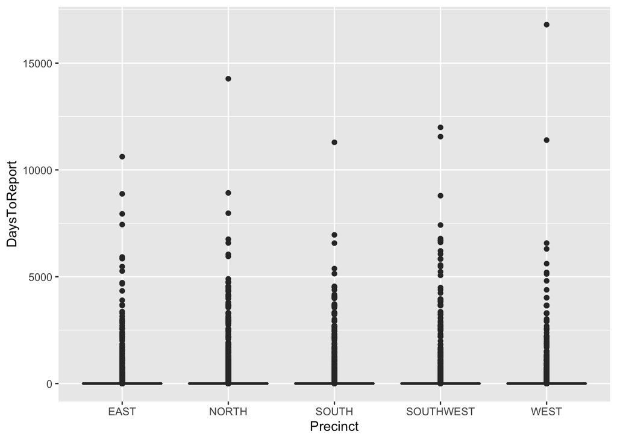

```r
# boxplot of days to report per precinct

library(ggplot2)
base=ggplot(data=crime,
            aes(x=Precinct,y=DaysToReport))

base + geom_boxplot()
```

The plot above would not give so much insight, there is so much noise. The fact is that a better summary would tell us more to consider:

```r
# using "summary" function
tapply(crime$DaysToReport,
       crime$Precinct, summary)
```

```
## $EAST
##      Min.   1st Qu.    Median      Mean   3rd Qu.      Max.
##     0.000     0.000     0.000     6.723     1.000 10622.000
##
## $NORTH
##      Min.   1st Qu.    Median      Mean   3rd Qu.      Max.
##     0.000     0.000     0.000     7.104     1.000 14268.000
##
## $SOUTH
##     Min.  1st Qu.   Median     Mean  3rd Qu.     Max.
##     0.00     0.00     0.00     7.22     1.00 11292.00
##
## $SOUTHWEST
##     Min.  1st Qu.   Median     Mean  3rd Qu.     Max.
##     0.00     0.00     0.00    11.06     1.00 11992.00
##
## $WEST
##      Min.   1st Qu.    Median      Mean   3rd Qu.      Max.
##     0.000     0.000     0.000     4.897     1.000 16801.000
```

From the information above, you know that for each precint, the 75% of crimes are reported in a day or less. If we consider that situation as the expected behavior, let me keep the ones that take more than a day. Let me explore by week or more using **ggarrange**:

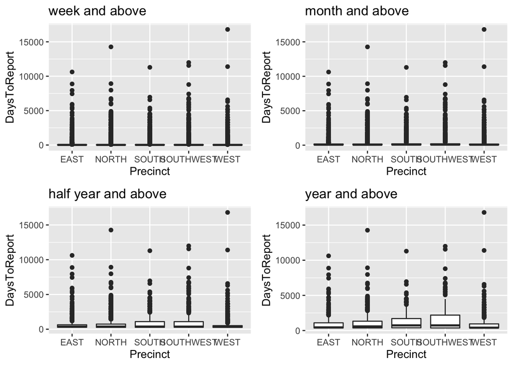

```r
# several boxplots, from week and above

library(ggpubr)

base7=ggplot(data=crime[crime$DaysToReport>=7,],
            aes(x=Precinct,y=DaysToReport))
box7=base7 + geom_boxplot() + labs(title = "week and above")

base30=ggplot(data=crime[crime$DaysToReport>=30,],
            aes(x=Precinct,y=DaysToReport))
box30=base30 + geom_boxplot() + labs(title = "month and above")

base180=ggplot(data=crime[crime$DaysToReport>=180,],
            aes(x=Precinct,y=DaysToReport))
box180=base180 + geom_boxplot() + labs(title = "half year and above")


base365=ggplot(data=crime[crime$DaysToReport>=365,],
            aes(x=Precinct,y=DaysToReport))
box365=base365 + geom_boxplot() + labs(title = "year and above")



#all in one:
ggarrange(box7,box30,box180,box365)
```

Up to this point, you need to be planing a good *story*. The situation is different for each case, but let’s build our visual from the crimes that take a year or longer to report.

```r
crimeYear=crime[crime$DaysToReport>365,]
```

Let me see if flipping helps you see better:

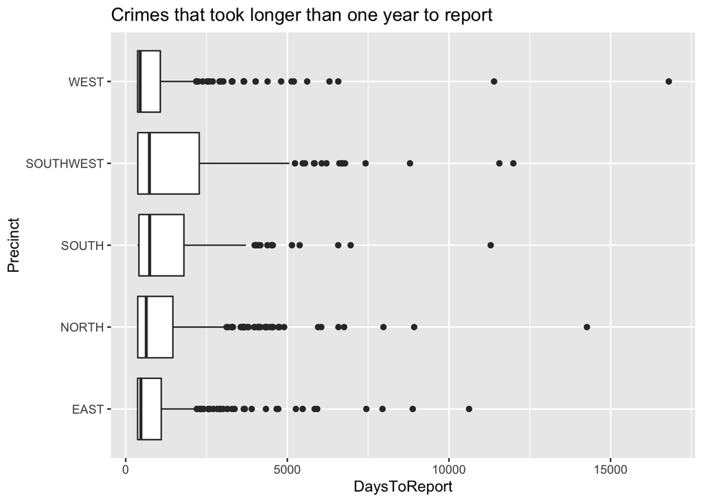

```r
baseYear=ggplot(data=crimeYear,
            aes(x=Precinct,
                y=DaysToReport))
boxYear=baseYear + geom_boxplot() + labs(title = "Crimes that took longer than one year to report")
# flipping
boxYear  + coord_flip()
```

It could be better if we **reorder** the category by the median of the numeric variable:

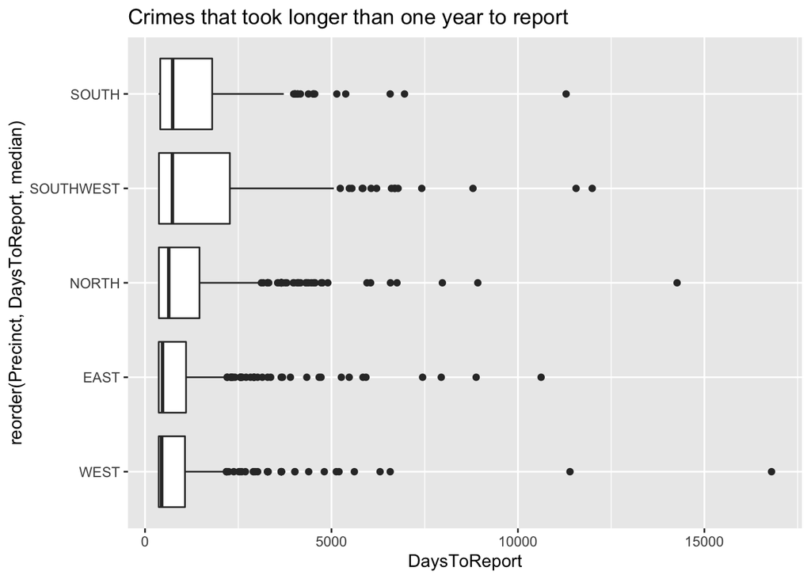

```r
baseYear=ggplot(data=crimeYear,
            aes(x=reorder(Precinct,
                          DaysToReport,
                          median),
                y=DaysToReport))
boxYear=baseYear + geom_boxplot() + labs(title = "Crimes that took longer than one year to report")
# flipping
boxYear  + coord_flip()
```

What if we use the histogram:

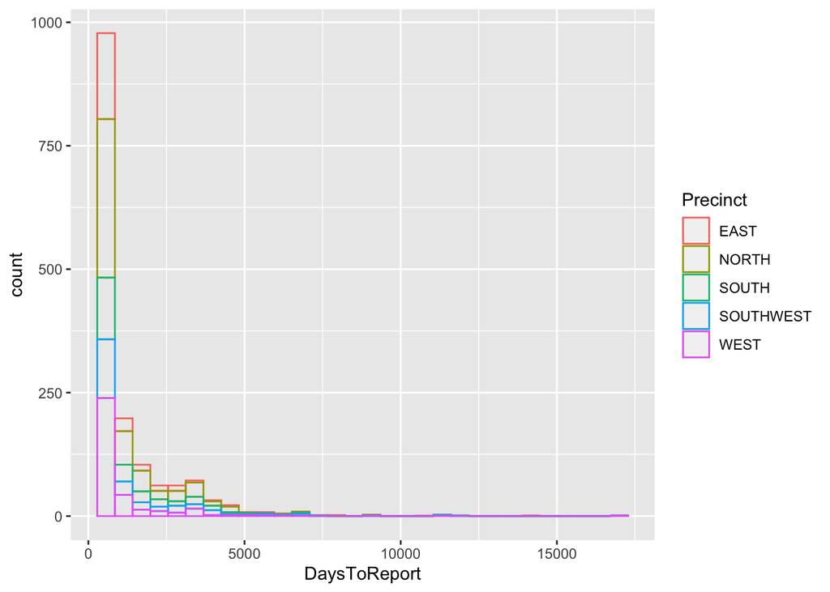

```r
baseHY=ggplot(data=crimeYear,
            aes(x=DaysToReport))
histY=baseHY + geom_histogram(aes(color=Precinct),
                              fill=NA)
# flipping
histY
```

You might prefer the use of facets:

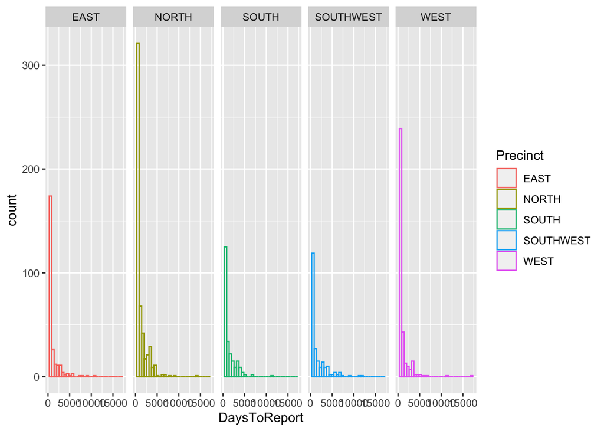

```r
histY + facet_grid(~Precinct)
```

Or…

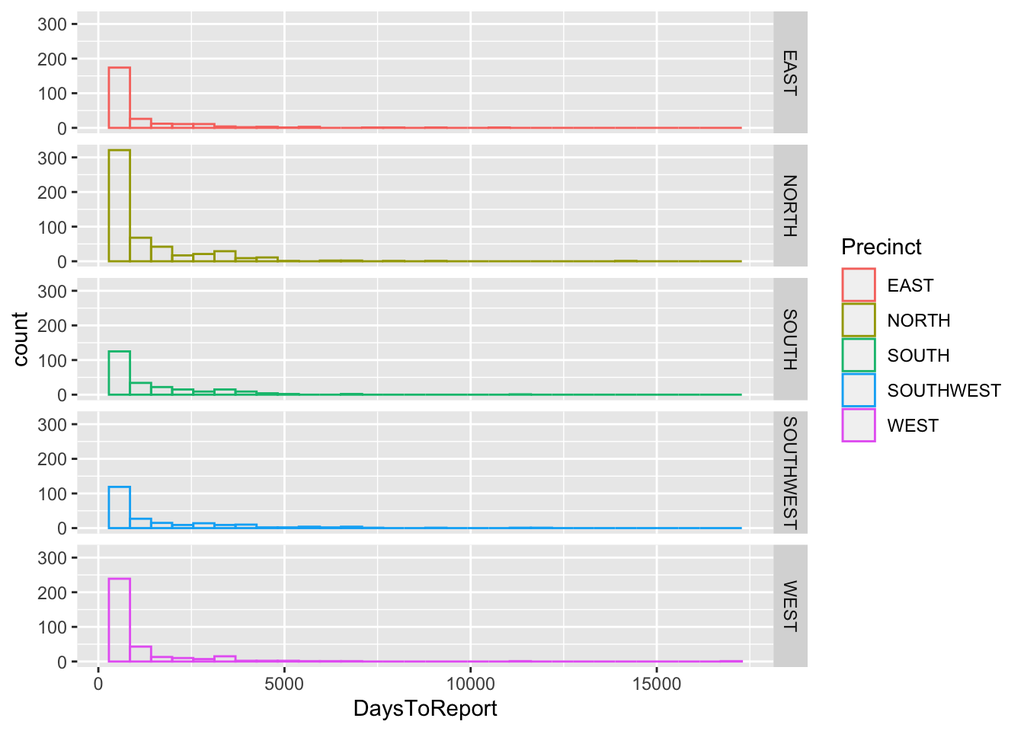

```r
histY + facet_grid(Precinct~.)
```

What about reordering:

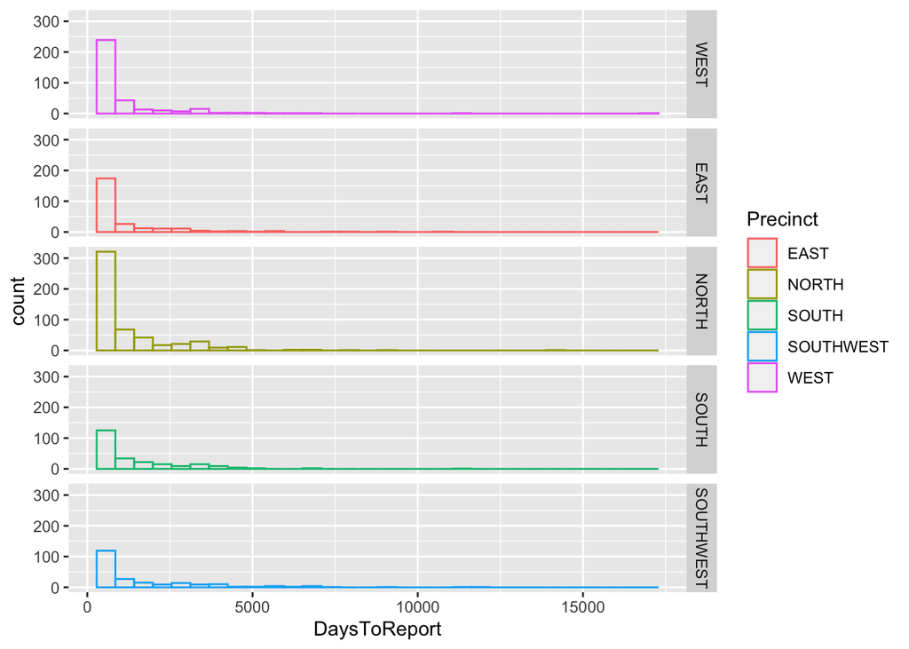

```r
histY= histY + facet_grid(reorder(Precinct,
                                  DaysToReport,
                                  mean)~.)
histY
```

Another common visual is the mean-error plot, which shows the mean of the numeric variable including a confidence interval. Let me first recall the two variables I have been using:

```r
crimeYear[,c('Precinct', 'DaysToReport')] %>%head(20)
```

```
##       Precinct DaysToReport
## 2122 SOUTHWEST          366
## 2886      WEST         1303
## 2901      WEST         1097
## 2977     NORTH          987
## 3029     SOUTH          475
## 4317     NORTH         1827
## 4502      WEST          367
## 5366 SOUTHWEST          727
## 6053      EAST          374
## 6084      EAST         1599
## 7019     NORTH          632
## 7020     NORTH          943
## 7914      EAST          366
## 7995      WEST        16801
## 7996     NORTH        14268
## 8003 SOUTHWEST        11559
## 8005      WEST        11396
## 8007 SOUTHWEST        11992
## 8011      EAST        10622
## 8012     SOUTH        11292
```

The plan is to show the mean per precinct:

```
## No summary function supplied, defaulting to `mean_se()`
```

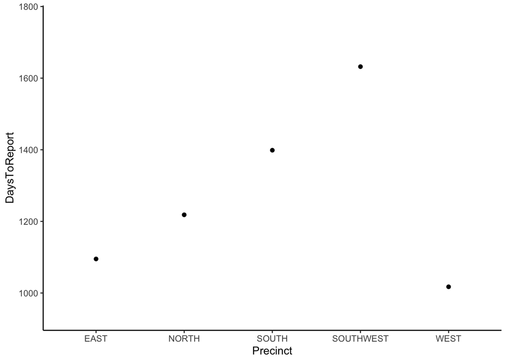

```r
baseMEANs=ggplot(crimeYear, aes(x=Precinct,
                             y=DaysToReport)) +
        theme_classic()
pointMEANS=baseMEANs + geom_point(stat="summary")
pointMEANS
```

We can add now the error bar:

```
## No summary function supplied, defaulting to `mean_se()`
## No summary function supplied, defaulting to `mean_se()`
```

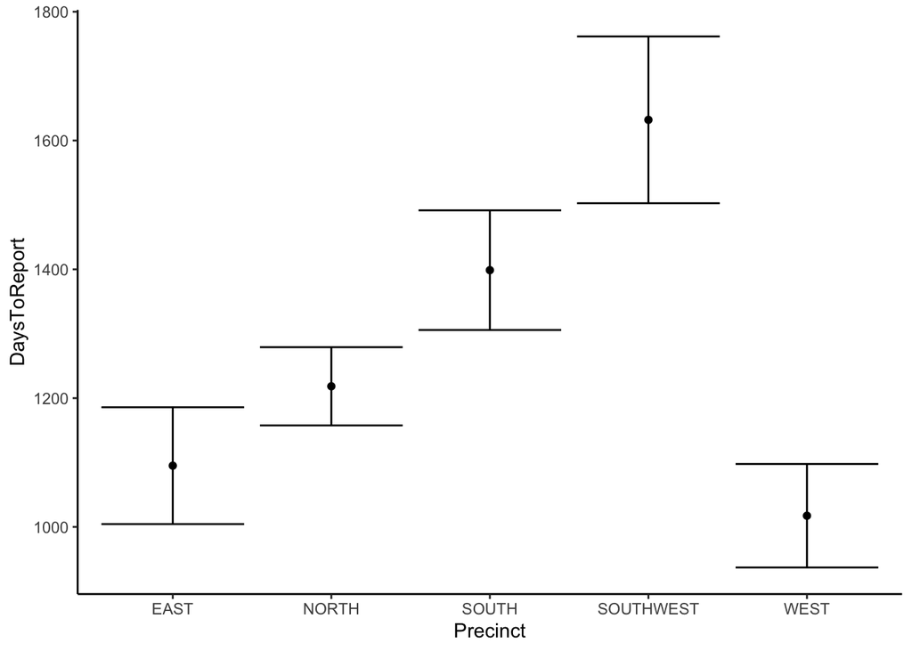

```r
pointMEANS=pointMEANS + geom_errorbar(stat="summary")
pointMEANS
```

Error bars have a **huge problem**, they give you the illusion of symmetry. So, I recommend you include the data in the plot:

```
## No summary function supplied, defaulting to `mean_se()`
## No summary function supplied, defaulting to `mean_se()`
```

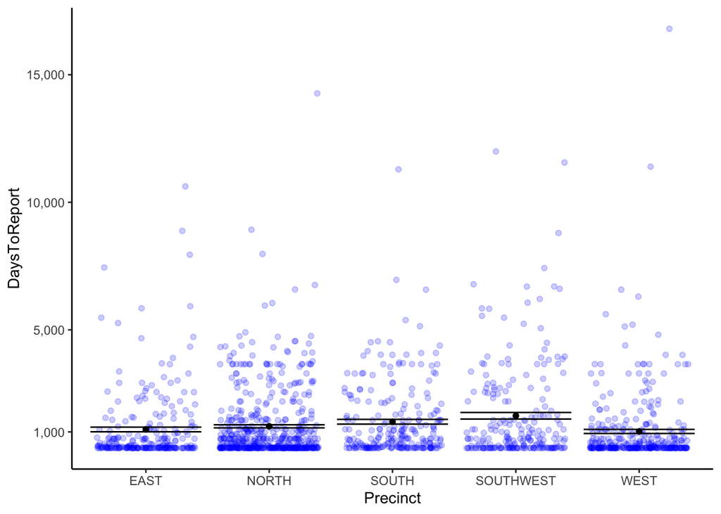

```r
baseMEANs= ggplot(crimeYear, aes(x=Precinct,
                      y=DaysToReport)) +
        theme_classic()
jitterMEANs= baseMEANs + geom_jitter(colour="blue",
                             alpha=0.2 #transparency
                             )
jitterMEANs=jitterMEANs + geom_point(stat="summary") +
             geom_errorbar(stat="summary")
jitterMEANs + scale_y_continuous(breaks = c(1000,5000, 10000,15000),labels = scales::comma)
```

This might be easier to produce if we use **ggpubr**:

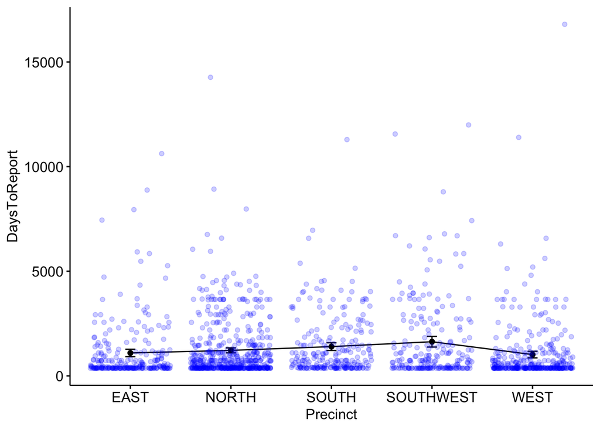

```r
# introducing ggpubr
library(ggpubr)

base = ggline(data=crimeYear,x = "Precinct",
       y = "DaysToReport",
       add = 'mean_ci')
base + geom_jitter(colour="blue",
                   alpha=0.2)
```

The Y axis may be easier to interpret if we turn the days into years and replot:

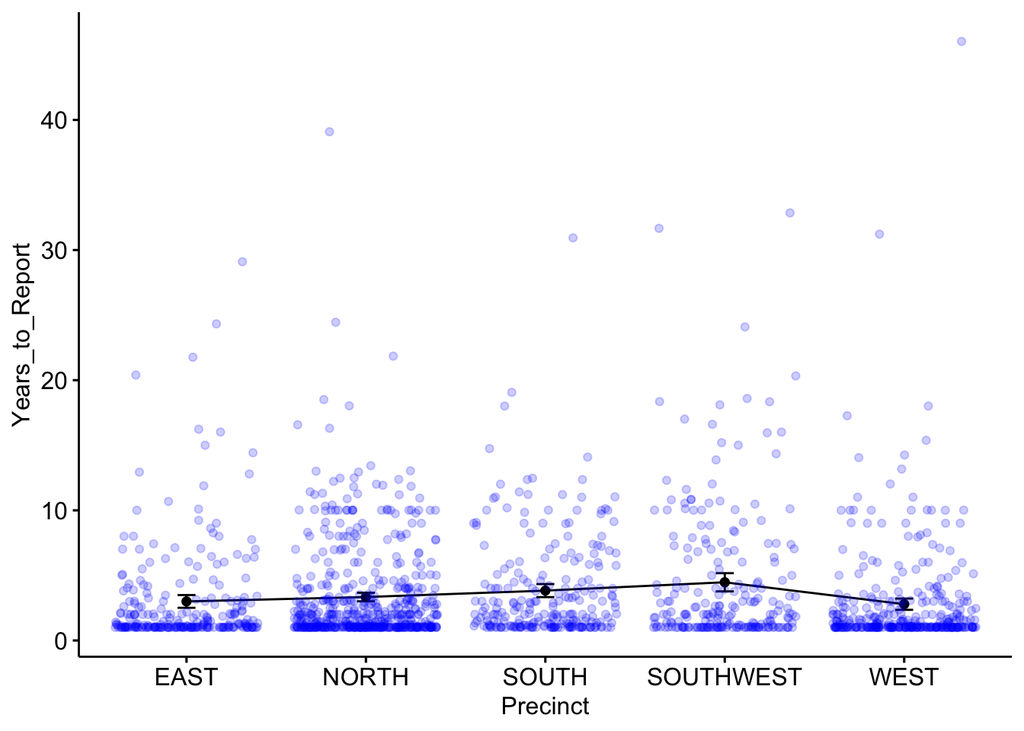

```r
crimeYear$Years_to_Report=crimeYear$DaysToReport/365
base = ggline(data=crimeYear,
              x = "Precinct",
              y = "Years_to_Report",
              add = 'mean_ci')
base + geom_jitter(colour="blue",
                   alpha=0.2)
```

Using the capabilities to compute statistics on the run, let’s invent a visual:

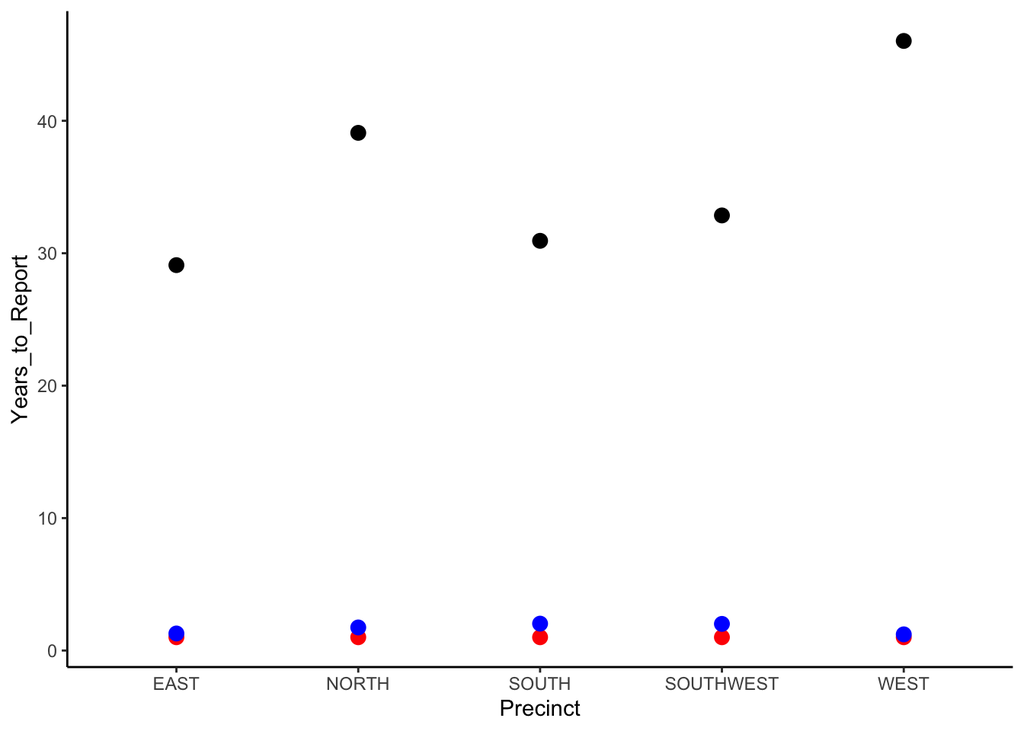

```r
baseINV=ggplot(crimeYear, aes(x=Precinct,
                             y=Years_to_Report)) +
        theme_classic()

#point for each stat
MINs=baseINV + geom_point(stat="summary",fun='max',size=3,)
MAXMINs=MINs + geom_point(stat="summary",fun='min',size=3,
                          color='red')
MxMnMDs=MAXMINs+ geom_point(stat="summary",size=3,
                            fun='median',
                            color='blue')
# logarithmic scale..custom breaks
MxMnMDs# + scale_y_log10()
```

The plot has colors but no legend. Legends activate when color appears as an **aes**. This may look tricky:

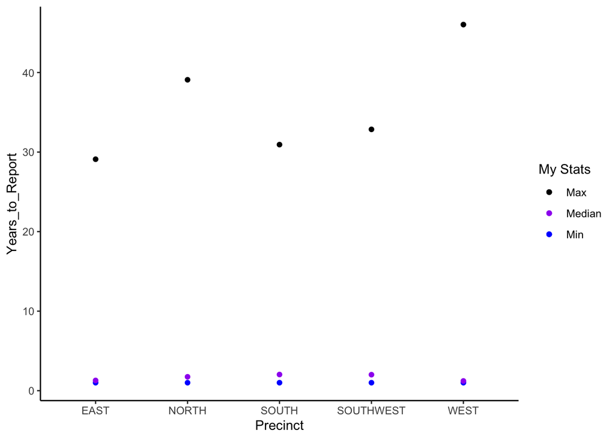

```r
# vector of colors named as stats:
myFunCols=c(Max='black',Min='blue',Median='purple')

# plotting
baseINV=ggplot(crimeYear, aes(x=Precinct,
                             y=Years_to_Report)) + theme_classic()
# points with AESthetics:
MINs=baseINV + geom_point(stat="summary",
                          fun='max',
                          aes(color="Max")) #change!
MAXMINs=MINs + geom_point(stat="summary",
                          fun='min',
                          aes(color="Min")) #change!
MxMnMDs=MAXMINs+ geom_point(stat="summary",
                            fun='median',
                            aes(color="Median")) #change!
#MxMnMDs= MxMnMDs + scale_y_log10(breaks=c(50,40,30,5,1))

# customizing legend:
MxMnMDs= MxMnMDs + scale_colour_manual(values=myFunCols,
                                       name="My Stats")
MxMnMDs
```

You can connect the dots as a visual aid, but I will reserve that for the plot using numerical data on the horizontal axis.